# A Wrinkle in Time

Author: Madeleine L’Engle

**“If you aren’t unhappy sometimes you don’t know how to be happy.”**

― Madeleine L’Engle, A Wrinkle in Time

[figure not shown]

## Summary

It was a dark and stormy night; Meg Murry, her small brother Charles Wallace, and her mother had come down to the kitchen for a midnight snack when they were upset by the arrival of a most disturbing stranger.

“Wild nights are my glory,” the unearthly stranger told them. “I just got caught in a downdraft and blown off course. Let me be on my way. Speaking of way, by the way, there is such a thing as a tesseract”.

Meg’s father had been experimenting with this fifth dimension of time travel when he mysteriously disappeared. Now the time has come for Meg, her friend Calvin, and Charles Wallace to rescue him. But can they outwit the forces of evil they will encounter on their heart-stopping journey through space?

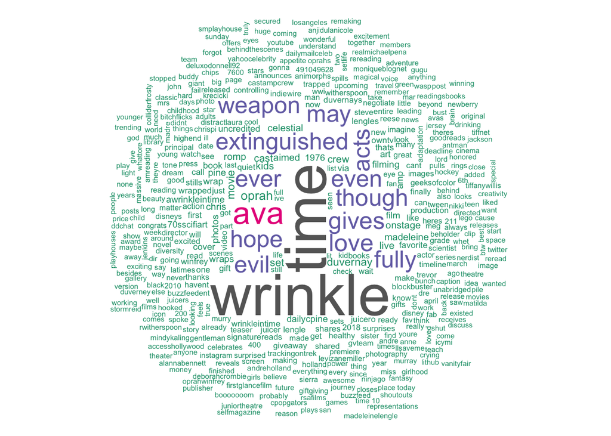

[output not shown]

[output not shown]

[figure not shown]

## Key Themes

- bookstomovies
- crossworlds
- strongfemaleleads
- classics

## Extras

- Time’s “100 Best Young Adult Books of All Time”
- Newbery Medal
- Oklahoma Sequoyah Book Award

summary from Goodreads

extras from Barnes & Noble